# ENV 790.30 - Time Series Analysis for Energy Data | Spring 2023

### Q9

Use the $auto.arima()$ command on the **deseasonalized series** to let R choose the model parameter for you. What’s the order of the best ARIMA model? Does it match what you specified in Q4?

```r
ARIMA_autofit <- auto.arima(deseasonal_NG,max.D=0,max.P = 0,max.Q=0)
print(ARIMA_autofit)
```

```
## Series: deseasonal_NG
## ARIMA(2,1,3) with drift
##
## Coefficients:
##           ar1     ar2     ma1      ma2      ma3      drift
##       -0.3019  0.6482  0.0546  -0.9126  -0.0860  -359.8849
## s.e.   0.0963  0.0930  0.1209   0.0495   0.0999    33.5706
##
## sigma^2 = 26790433:  log likelihood = -2380.74
## AIC=4775.49   AICc=4775.97   BIC=4799.82
```

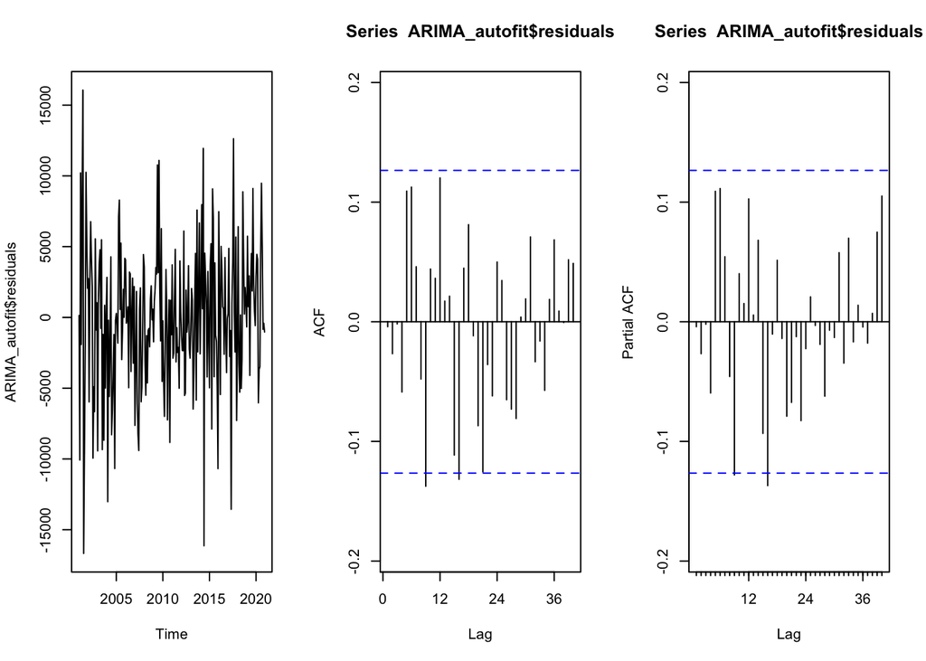

```r
par(mfrow=c(1,3))
ts.plot(ARIMA_autofit$residuals)
Acf(ARIMA_autofit$residuals,lag.max=40)
Pacf(ARIMA_autofit$residuals,lag.max=40)
```

### Q10

Use the $auto.arima()$ command on the **original series** to let R choose the model parameters for you. Does it match what you specified in Q7?

> Answer: It doesn’t match what I specified in Q7. I specified (2,1,2) (0,1,1), but R’s selection is (2,0,1)(2,1,2)

```r
SARIMA_autofit <- auto.arima(ts_energy_df_NG)
print(SARIMA_autofit)
```

```
## Series: ts_energy_df_NG
## ARIMA(2,0,1)(2,1,2)[12] with drift
##
## Coefficients:
##          ar1      ar2      ma1     sar1     sar2     sma1    sma2      drift
##       1.1650  -0.2834  -0.4837  -0.0667  -0.0785  -0.6371  0.0072  -357.8436
## s.e.  0.4164   0.3180   0.3993   1.3208   0.1014   1.3201  0.9205    44.1284
##
## sigma^2 = 27958166:  log likelihood = -2278.46
## AIC=4574.91   AICc=4575.74   BIC=4605.77
```

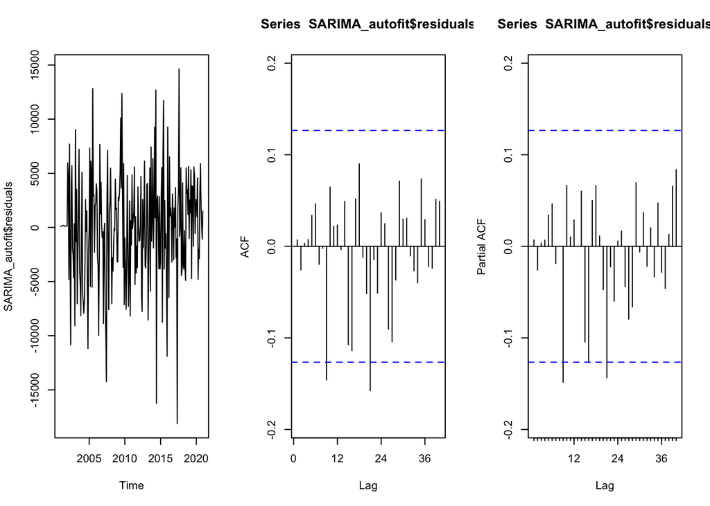

```r
par(mfrow=c(1,3))
ts.plot(SARIMA_autofit$residuals)
Acf(SARIMA_autofit$residuals,lag.max=40)
Pacf(SARIMA_autofit$residuals,lag.max=40)
```